# Coursera, Data Science, Reproducible Research, Assessment1

### Installing or loading packages.

Chron is for easily determining whether a date is on a weekend or not.

```r
if(!require(chron)){
    install.packages("chron")
    library(chron)
}
if(!require(lattice)){
    install.packages("lattice")
    library(lattice)
}
```

## Loading and preprocessing the data

Unzipping the file.

```r
unzip("./activity.zip", overwrite = TRUE)
```

Assigning the *.csv-file* to **activity_data**.

```r
activity_data <- read.csv("./activity.csv")
```

Formatting the date as date class.

```r
activity_data$date <- as.Date(activity_data$date, "%Y-%m-%d")
```

## What is mean total number of steps taken per day?

Aggregating the total steps by days.

```r
daily_steps <- aggregate(steps ~ date, data = activity_data, sum, na.rm = TRUE)
```

Creating the histogram.

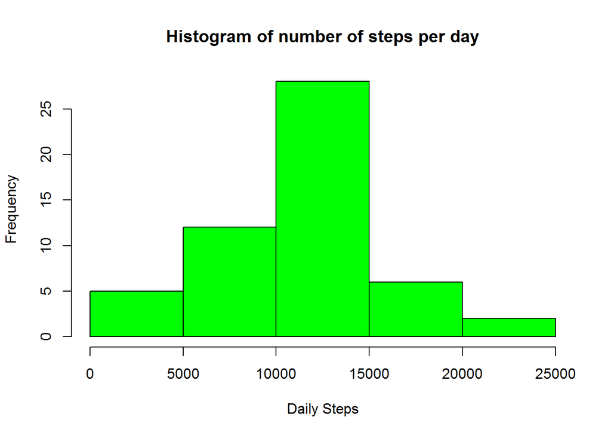

```r
hist(daily_steps$steps, xlab = "Daily Steps", main = "Histogram of number of steps per day", col = "green")
```

The mean number of steps taken per day is:

```r
mean(daily_steps$steps)
```

```
## [1] 10766.19
```

The median number of steps taken per day is:

```r
median(daily_steps$steps)
```

```
## [1] 10765
```

## What is the average daily activity pattern?

Calculating the average number of steps in an interval.

```r
interval_mean <- aggregate(steps ~ interval, data = activity_data, mean, na.rm = TRUE)
```

Generating the time series plot.

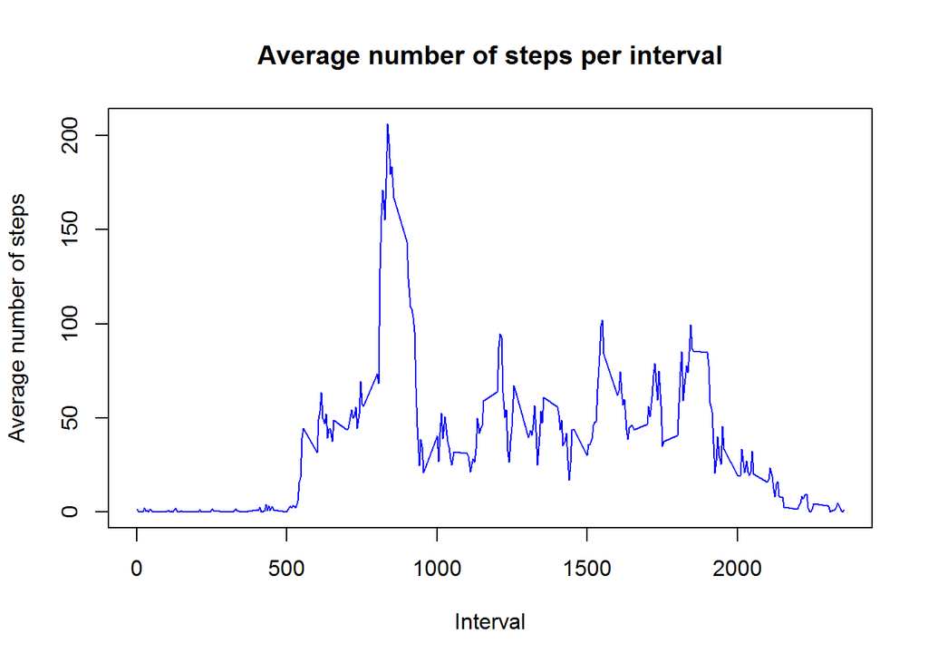

```r
plot(x = interval_mean$interval, y = interval_mean$steps, type = "l", main = "Average number of steps per interval", xlab = "Interval", ylab = "Average number of steps", col = "blue")
```

The 5-minute interval which contains the maximum average number of steps.

```r
interval_mean[which.max(interval_mean$steps),]
```

```
##     interval    steps
## 104      835 206.1698
```

## Imputing missing values.

The number of missing values in the data set.

```r
missings <- sum(is.na(activity_data$steps))
```

The number of missings is 2304.

Replacing missing values with the average value from the same interval. Imputed data set created.

```r
imputed <- numeric()

for (i in 1:nrow(activity_data)) {
    row <- activity_data[i, ]
    if (is.na(row$steps)) {
      filler <- subset(interval_mean, interval == row$interval)$steps
    } else {
      filler <- row$steps
    }
    imputed <- c(imputed, filler)
}

activity_imputed <- activity_data
activity_imputed$steps <- imputed
```

Imputed data set is used to summarize the total number of steps by day.

```r
daily_steps_imputed <- aggregate(steps ~ date, data = activity_imputed, sum, na.rm = TRUE)
```

Imputed data set is used to repeat the process to create the histogram.

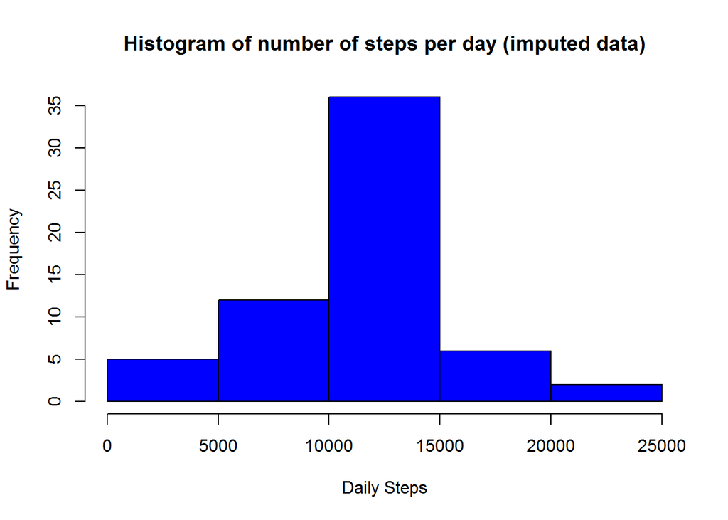

```r
hist(daily_steps_imputed$steps, xlab = "Daily Steps", main = "Histogram of number of steps per day (imputed data)", col = "blue")
```

The mean number of steps taken per day with the imputed data is:

```r
mean(daily_steps_imputed$steps)
```

```
## [1] 10766.19
```

The median number of steps taken per day with the imputed data is:

```r
median(daily_steps_imputed$steps)
```

```
## [1] 10766.19
```

## Are there differences in activity patterns between weekdays and weekends?

The mean and median are now identical and both have the value of the unimputed mean.

```r
activity_imputed$weekend <- is.weekend(activity_imputed$date)
class(activity_imputed$weekend)
```

```
## [1] "logical"
```

Averaging the number of steps by interval and whether its a weekend or not.

```r
interval_mean_imputed <- aggregate(steps ~ interval + weekend, data = activity_imputed, mean, na.rm = TRUE)
head(interval_mean_imputed)
```

```
##   interval weekend      steps
## 1        0   FALSE 2.25115304
## 2        5   FALSE 0.44528302
## 3       10   FALSE 0.17316562
## 4       15   FALSE 0.19790356
## 5       20   FALSE 0.09895178
## 6       25   FALSE 1.59035639
```

Creating the plot, weekend on top, weekdays at the bottom.

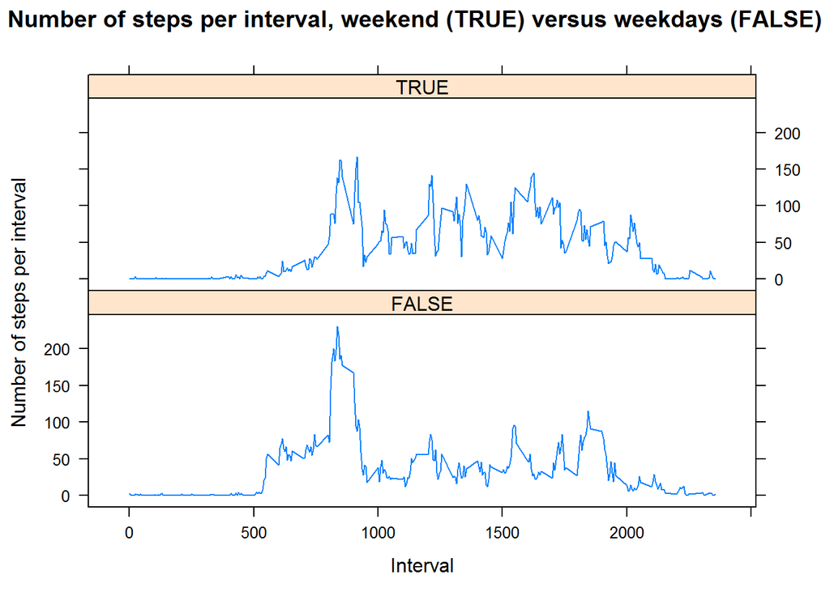

```r
xyplot(steps ~ interval | weekend, interval_mean_imputed, type = "l", layout = c(1, 2),
    xlab = "Interval", ylab = "Number of steps per interval", main = "Number of steps per interval, weekend (TRUE) versus weekdays (FALSE)")
```

It seems that the step activity spikes in the morning during weekdays and is more evenly distributed during weekends.